# Lab05: Clean Data

Daniel Escriba

2023-11-09

# LAB 05: Limpieza de Datos

## 1. Utilizando el dataset de la ENAHO revise la distribución de las edades para cada género, utilice la función: hist()

```r
# load csv

df_data <- read.csv("brecha_salarial_2020_1T.csv")

#Convertimos sexo en variable nominal

df_data[["sexo"]]<-factor(df_data[["sexo"]])

library(tidyverse)
```

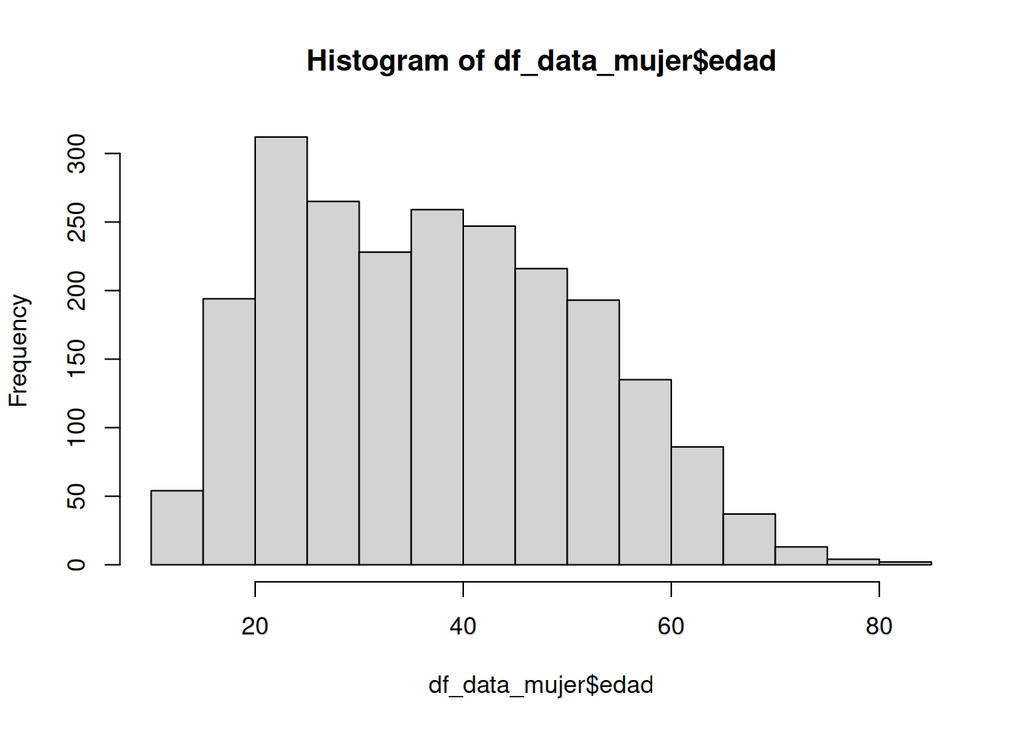

```r
# histograma por genero

df_data_mujer <- df_data |>
  filter(sexo == "mujer")

df_data_hombre <- df_data |>
  filter(sexo == "hombre")


hist(df_data_mujer$edad)
```

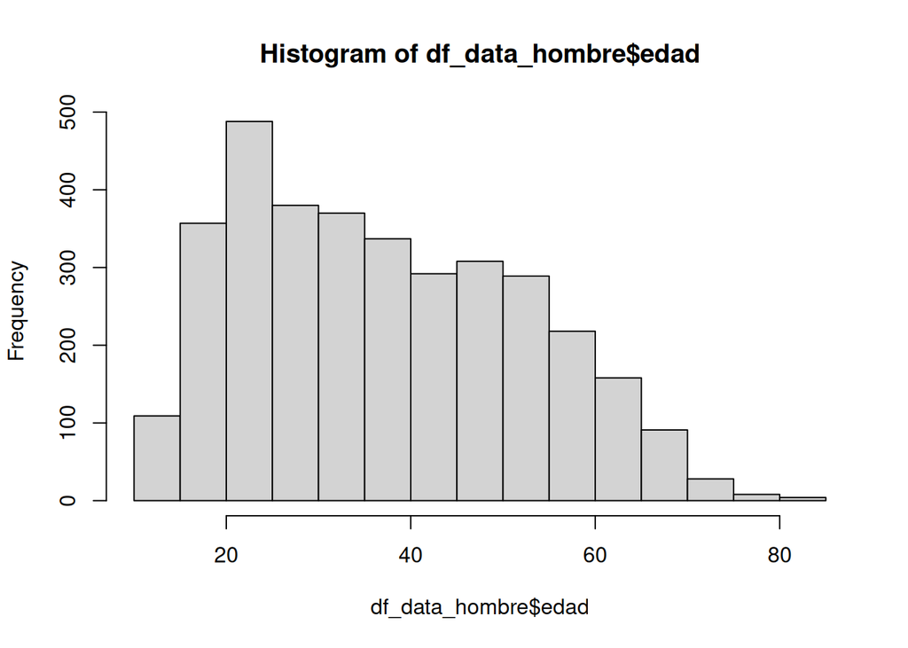

```r
hist(df_data_hombre$edad)
```

## 2. Revise la distribución de las remuneraciones

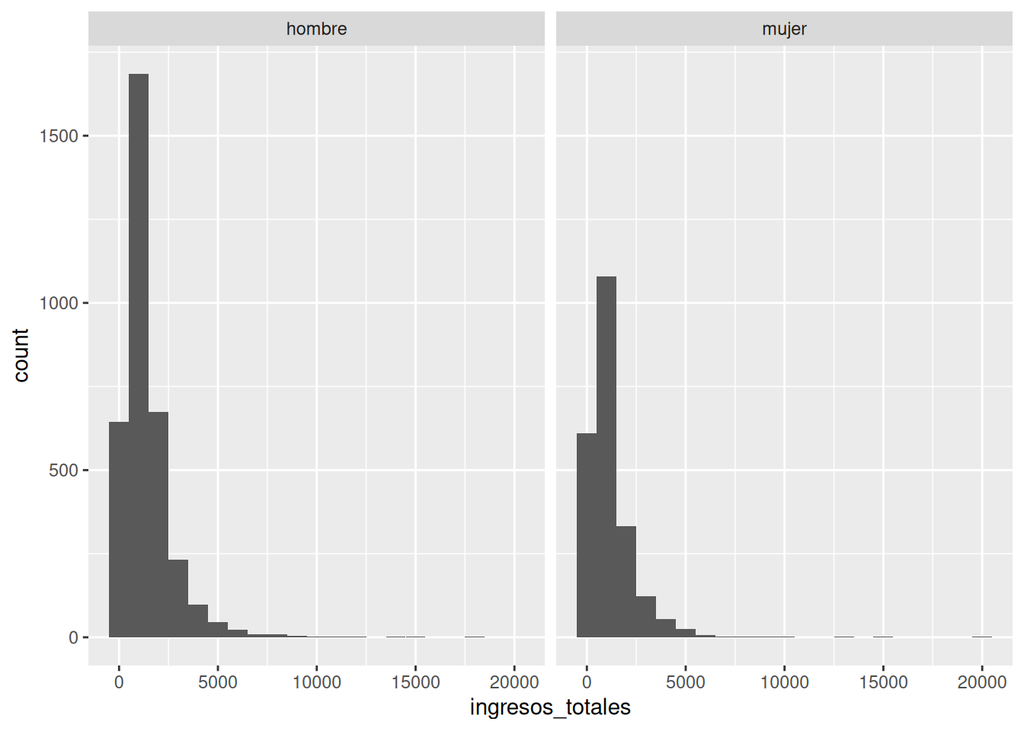

```r
# histograma de remuneración con ggplot
df_data %>%
  ggplot(aes(x = ingresos_totales)) +
  geom_histogram(binwidth = 1000) +
  facet_wrap(vars(sexo))
```

## 3. ¿Qué puede observar sobre la distribución de las remuneraciones?

> De primera impresion se puede observar que hay una mayor concentracion de sueldos entre 0 y 5000 soles, para ambos generos. Asimismo, la renumeracion de hombres presenta una mayor cantidad insidencias con respecto a mujeres.

## 4. Una de las técnicas que se utilizan en economía y estadística es linealizar algunas variables que tienen asimetría positiva utilizando la función logaritmo, utilice la función log a los ingresos y vuelva a realizar el histograma, ¿qué observa?.

> Se puede observar que la grafica es mas amigable y centrada para sacar el analisis previo.

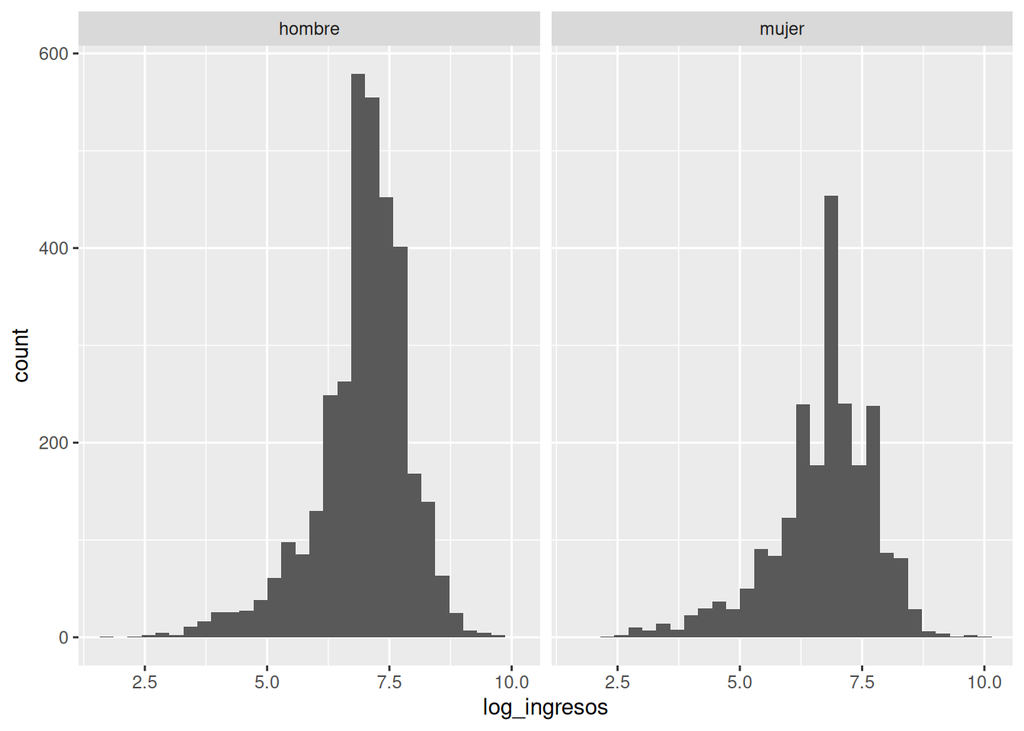

```r
# histograma de log(remuneración) con ggplot

df_data[["log_ingresos"]] <- log(df_data[["ingresos_totales"]])

df_data %>%
  ggplot(aes(x = log_ingresos)) +
  geom_histogram() +
  facet_wrap(vars(sexo))
```

## 5. Uno de los gráficos más útiles que existen para revisar la distribución de un vector de valores es el diagrama de cajas que tiene la estructura que se presenta a continuación.

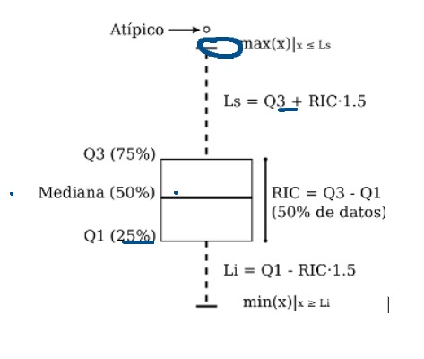

Utilicemos las funciones en R para obtener los cuartiles, para ello utilizaremos la función quantile que acepta 2 parámetros: vector de valores y la frecuencia relativa acumulada, así por ejemplo, si queremos el Q1 que es el valor que acumula el 25% de las observaciones se escribe: quantile(ingresos, 0.25)

Si deseamos obtener el Q2 que acumula el 50% se escribirá: quantile(ingresos, 0.50)

### ¿Cómo se le conoce a Q2?

> Q2 (0.50) - Tambien es conocido como la Mediana.

El Rango Intercuartílico, RIC, se define como la diferencia de Q3 – Q1, calcule este valor.

Los bigotes se obtienen multiplicando el RIC * 1.5 y sumando a Q3 o restando a Q1, los valores que se encuentran fuera de valores se denominan atípicos.

Calcule todas las estadísticas requeridas la caja de los ingresos de los hombres.

Tarea: realice los mismos cálculos para los ingresos de las mujeres.

En R existe una función que hace los cálcuos y gráfico de cajas por nosotros, la función se llama boxplot, utilice la función para obtener el gráfico de cajas de la los ingresos de hombres:

boxplot(ingresos_hombres)

La función boxplot también permite segmentar por medio de una variable categórica y acepta la nomenclatura de fórmula y un parámetro adicional de datos que hace referencia a un data frame.

boxplot( ingresos ~ sexo, df_datos)

## ¿Qué puede concluir de ese diagrama?

> Se puede observar que al retirtar los outliers, se puede manejar un mejor rango. Los ingresos de hombres sigue siendo mayor que el de las mujeres; Pero al tener valores altos, es medianamente complicado sacar conclusiones directas de los boxplot.

```r
# Obteniendo cuartiles y el IRQ
# calculos para hombres y mujeres

df_data %>%
  group_by(sexo) %>%
  select(ingresos_totales) %>%
  summarize( q2  = quantile(ingresos_totales, 0.50),
             q1  = quantile(ingresos_totales, 0.25),
             q3  = quantile(ingresos_totales, 0.75),
             irq = q3 - q1,
             li  = q1 - 1.5 * irq,
             ls  = q3 + 1.5 * irq)
```

```
## # A tibble: 2 × 7
##   sexo      q2    q1    q3   irq    li    ls
##   <fct>  <dbl> <dbl> <dbl> <dbl> <dbl> <dbl>
## 1 hombre  1200   720  1800  1080  -900  3420
## 2 mujer    930   500  1500  1000 -1000  3000
```

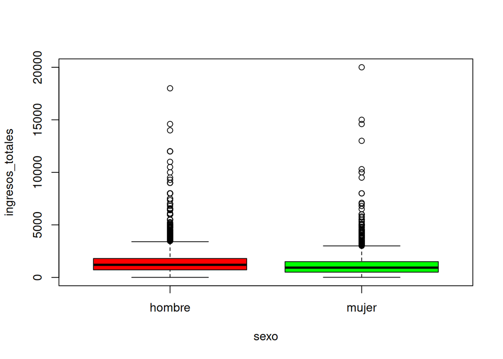

```r
# implementado el boxplot

boxplot(ingresos_totales ~ sexo, data = df_data, col=c('red','green'))
```

## 6. Mejore el diagrama aplicando la función log a los ingresos, ¿Qué puede concluir sobre los ingresos por género?

> Al implementar log a ingresos, nos da valores mas cortos. Lo cual, nos permite realizar mejor el analisis. Ahora se puede observar, igual que el anterior que el ingreso de hombres es mayor que mujeres. Pero al obsevar de mujeres se que tiene mayor amplitud IRQ, lo cual demuestra mayor dispercion en los ingresos.

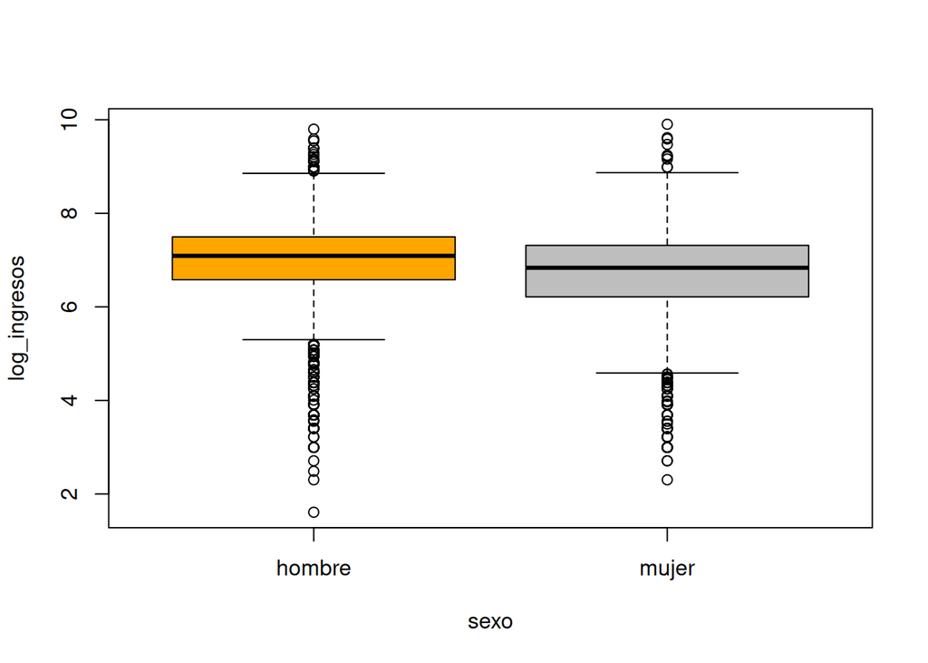

```r
# utilizando log (ingresos)

boxplot(log_ingresos ~ sexo, data = df_data, col=c('orange','grey'))
```

## 7. Realice un diagrama de dispersión de ingresos por edad.

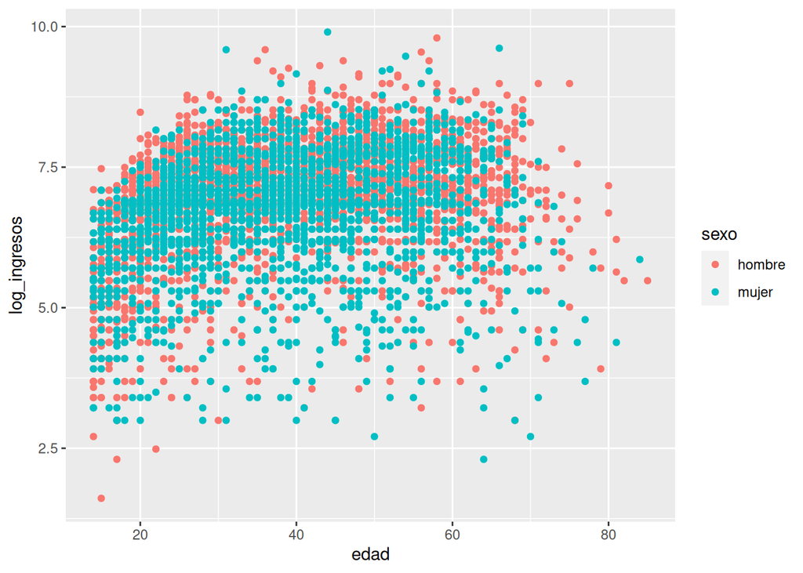

```r
df_data %>% ggplot(aes( x = edad, y = log_ingresos, color = sexo)) +
  geom_point()
```

## 8.Plantee una regresión lineal entre ingresos y edad, grafique la línea de regresión sobre el diagrama de dispersión.

```r
# modelo  variable sexo

df_data_modelo <-df_data %>%
  group_by(sexo) %>%
  select(log_ingresos,edad,sexo) %>%
  summarize( log_ingresos,
             edad,
             sexo,
             q2  = quantile(log_ingresos, 0.50),
             q1  = quantile(log_ingresos, 0.25),
             q3  = quantile(log_ingresos, 0.75),
             irq = q3 - q1,
             li  = 0,
             ls  = q3 + 1.5 * irq)|>
  filter(log_ingresos>li & log_ingresos<ls)|>
  select ( log_ingresos, edad, sexo)
mod_1 <- lm( log_ingresos ~ edad + sexo,
             data = df_data_modelo)

summary(mod_1)
```

```
##
## Call:
## lm(formula = log_ingresos ~ edad + sexo, data = df_data_modelo)
##
## Residuals:
##     Min      1Q  Median      3Q     Max
## -4.9569 -0.3979  0.1625  0.6063  2.2447
##
## Coefficients:
##               Estimate Std. Error t value Pr(>|t|)
## (Intercept)  6.3355078  0.0365334 173.417   <2e-16 ***
## edad         0.0153882  0.0008697  17.694   <2e-16 ***
## sexomujer   -0.2343866  0.0260874  -8.985   <2e-16 ***
## ---
## Signif. codes:  0 '***' 0.001 '**' 0.01 '*' 0.05 '.' 0.1 ' ' 1
##
## Residual standard error: 0.9586 on 5643 degrees of freedom
## Multiple R-squared:  0.06498,    Adjusted R-squared:  0.06465
## F-statistic: 196.1 on 2 and 5643 DF,  p-value: < 2.2e-16
```

```r
# modelos separados
# para mujeres

df_data_modelo_m <- df_data_modelo |>
  filter( sexo == "mujer" ) |>
  select ( log_ingresos, edad, sexo)


mod_1_m <- lm( log_ingresos ~ edad,
             data = df_data_modelo_m)

summary(mod_1_m)
```

```
##
## Call:
## lm(formula = log_ingresos ~ edad, data = df_data_modelo_m)
##
## Residuals:
##     Min      1Q  Median      3Q     Max
## -4.6882 -0.4578  0.1882  0.6614  2.2278
##
## Coefficients:
##             Estimate Std. Error t value Pr(>|t|)
## (Intercept) 6.237392   0.062293 100.129  < 2e-16 ***
## edad        0.011772   0.001549   7.599 4.36e-14 ***
## ---
## Signif. codes:  0 '***' 0.001 '**' 0.01 '*' 0.05 '.' 0.1 ' ' 1
##
## Residual standard error: 1.028 on 2233 degrees of freedom
## Multiple R-squared:  0.02521,    Adjusted R-squared:  0.02477
## F-statistic: 57.75 on 1 and 2233 DF,  p-value: 4.361e-14
```

```r
# para hombres
df_data_modelo_h <- df_data_modelo |>
  filter( sexo == "hombre" ) |>
  select ( log_ingresos, edad, sexo)


mod_1_h <- lm( log_ingresos ~ edad,
             data = df_data_modelo_h)

summary(mod_1_h)
```

```
##
## Call:
## lm(formula = log_ingresos ~ edad, data = df_data_modelo_h)
##
## Residuals:
##     Min      1Q  Median      3Q     Max
## -4.9105 -0.3906  0.1509  0.5789  2.0677
##
## Coefficients:
##             Estimate Std. Error t value Pr(>|t|)
## (Intercept) 6.258259   0.041764  149.85   <2e-16 ***
## edad        0.017447   0.001033   16.89   <2e-16 ***
## ---
## Signif. codes:  0 '***' 0.001 '**' 0.01 '*' 0.05 '.' 0.1 ' ' 1
##
## Residual standard error: 0.9087 on 3409 degrees of freedom
## Multiple R-squared:  0.07725,    Adjusted R-squared:  0.07698
## F-statistic: 285.4 on 1 and 3409 DF,  p-value: < 2.2e-16
```

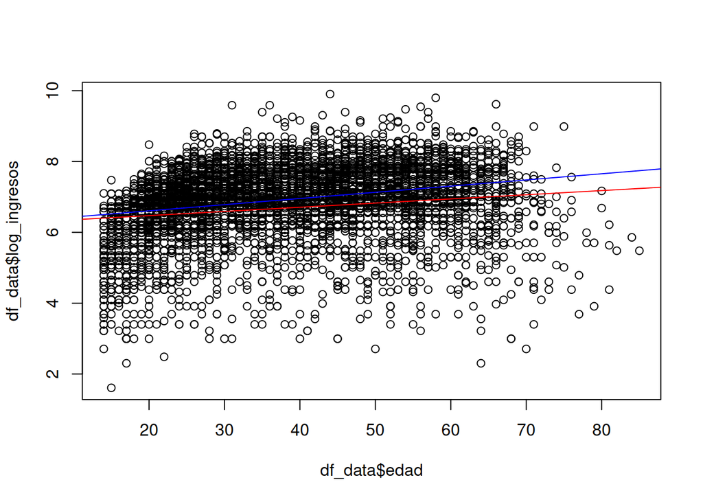

```r
# graficamos
plot(x = df_data$edad, y = df_data$log_ingresos) # grafica el diagrama de dispersión
abline(mod_1_m, col="red" ) # añade la línea de regresión
abline(mod_1_h, col="blue" ) # añade la línea de regresión
```

## 9. Plantee un gráfico de y vs y_estimado, ¿Qué puede concluir?

> Al hace predicciones originales, se puede observar que en un estimado de tiempo los sueldo aumentaran, pero se mantedran las diferencias entre ambos generos, siempre y cuando no se haga un cambio significativo.

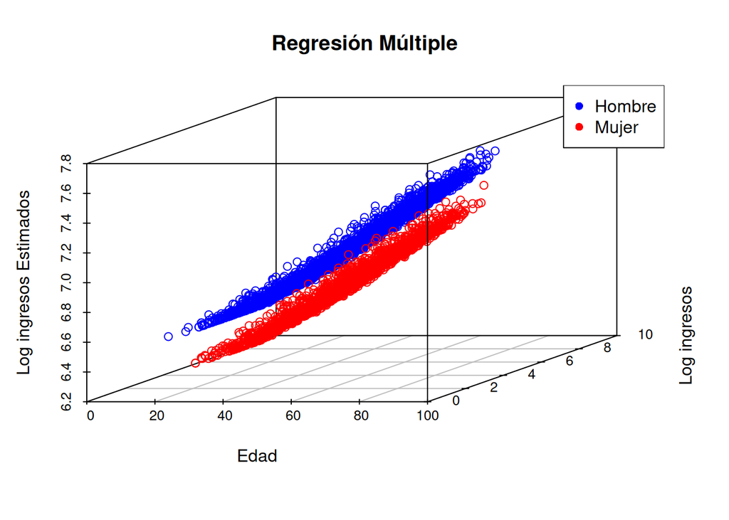

```r
library(scatterplot3d)

mi_3d <- scatterplot3d(x=df_data_modelo$edad,
                       y=df_data_modelo$log_ingresos,
                       mod_1$fitted.values,
                       color = ifelse(df_data_modelo$sexo == "mujer", "red", "blue"),
                       main = "Regresión Múltiple",
                       xlab = "Edad",
                       ylab = "Log ingresos",
                       zlab = "Log ingresos Estimados"
                       )

legend("topright", legend = c("Hombre", "Mujer"), col = c("blue", "red"), pch = c(16))
```

# 10. Plantee un modelo de regresión lineal multiple

> Para el ejercicio, se tomara datos del Ministerio de educacion del peru, asimismo, se tomara como mitad de tiempo de estudios en casos de educacion incompleta. Los datos a tomar seran:

```r
df_anios_escolaridad <- data.frame(
  estudios = c("sin nivel","inicial","primaria incompleta","primaria completa",
               "secundaria incompleta","secundaria completa","superior no universitaria incompleta","superior no universitaria completa",
               "superior universitaria incompleta","superior universitaria completa","maestria/doctorado","basica especial" ),
  anios = c(0,2,3,6,2.5,5,1.5,3,2.5,5,5,20),
  anios_escolaridad = c(0,2,5,8,10.5,13,14.5,16,15.5,18,23,20)
)

print(df_anios_escolaridad)
```

```
##                                estudios anios anios_escolaridad
## 1                             sin nivel   0.0               0.0
## 2                               inicial   2.0               2.0
## 3                   primaria incompleta   3.0               5.0
## 4                     primaria completa   6.0               8.0
## 5                 secundaria incompleta   2.5              10.5
## 6                   secundaria completa   5.0              13.0
## 7  superior no universitaria incompleta   1.5              14.5
## 8    superior no universitaria completa   3.0              16.0
## 9     superior universitaria incompleta   2.5              15.5
## 10      superior universitaria completa   5.0              18.0
## 11                   maestria/doctorado   5.0              23.0
## 12                      basica especial  20.0              20.0
```

```r
## verficando si la columna estudio esta limpia

print(any(is.na(df_data$estudios))) #na
```

```
## [1] FALSE
```

```r
cantidad_vacios <- sum(df_data$estudios == "") #string vacios
print(cantidad_vacios) #se encontro solo 1, no supera el 10%
```

```
## [1] 1
```

```r
## dropping Data

print(names(df_data))
```

```
##  [1] "sexo"             "ubigeo"           "nom_region"       "nom_provincia"
##  [5] "nom_distrito"     "ocupinf"          "ingresos_totales" "estudios"
##  [9] "edad"             "anio"             "mes"              "estrato"
## [13] "tipo_contrato"    "tamanio_empresa"  "p507"             "p510"
## [17] "log_ingresos"
```

```r
df_data_estudios <- filter(df_data, estudios != "")

str(df_data$estudios)
```

```
##  chr [1:5682] "secundaria completa" "superior universitaria completa" ...
```

```r
str(df_data_estudios$estudios)
```

```
##  chr [1:5681] "secundaria completa" "superior universitaria completa" ...
```

```r
# Mostrar los datos presentes en la columna

print(unique(df_data_estudios$estudios))
```

```
##  [1] "secundaria completa"
##  [2] "superior universitaria completa"
##  [3] "secundaria incompleta"
##  [4] "maestria/doctorado"
##  [5] "primaria incompleta"
##  [6] "superior no universitaria completa"
##  [7] "primaria completa"
##  [8] "sin nivel"
##  [9] "superior no universitaria incompleta"
## [10] "superior universitaria incompleta"
## [11] "b\xa0sica especial"
## [12] "inicial"
```

```r
# corregir dato de eduacion basica especial
df_data_estudios <- df_data_estudios %>%
  mutate(estudios = ifelse(estudios == 'b\xa0sica especial', 'basica especial', estudios))

print(unique(df_data_estudios$estudios))
```

```
##  [1] "secundaria completa"
##  [2] "superior universitaria completa"
##  [3] "secundaria incompleta"
##  [4] "maestria/doctorado"
##  [5] "primaria incompleta"
##  [6] "superior no universitaria completa"
##  [7] "primaria completa"
##  [8] "sin nivel"
##  [9] "superior no universitaria incompleta"
## [10] "superior universitaria incompleta"
## [11] "basica especial"
## [12] "inicial"
```

```r
# incluir la nueva columna anios de escolaridad.

# Realizar left join basado en la columna 'estudios'
df_data_estudios <- left_join(df_data_estudios, df_anios_escolaridad, by = "estudios") %>%
  select(-anios)  # Excluir la columna 'anios' de df_escolaridad
```

## b. Aplique las técnicas reseñadas en la parte de teoría para eliminar los outliers.

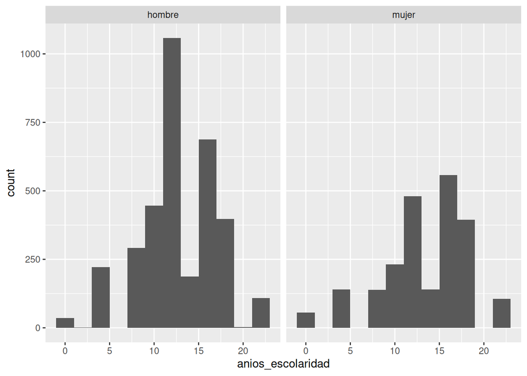

```r
# imprimir histogramas

df_data_estudios %>%
  ggplot(aes(x = anios_escolaridad)) +
  geom_histogram(binwidth = 2) +
  facet_wrap(vars(sexo))
```

```r
# Aplicando las tecnica para eliminar outliers

df_data_estudios <-df_data_estudios %>%
  group_by(sexo) %>%
  select(anios_escolaridad,edad,sexo) %>%
  summarize( anios_escolaridad,
             edad,
             sexo,
             q2  = quantile(anios_escolaridad, 0.50),
             q1  = quantile(anios_escolaridad, 0.25),
             q3  = quantile(anios_escolaridad, 0.75),
             irq = q3 - q1,
             li  = q1 - 1.5 * irq,
             ls  = q3 + 1.5 * irq)|>
  filter(anios_escolaridad>li & anios_escolaridad<ls)|>
  select (anios_escolaridad, edad, sexo)
```

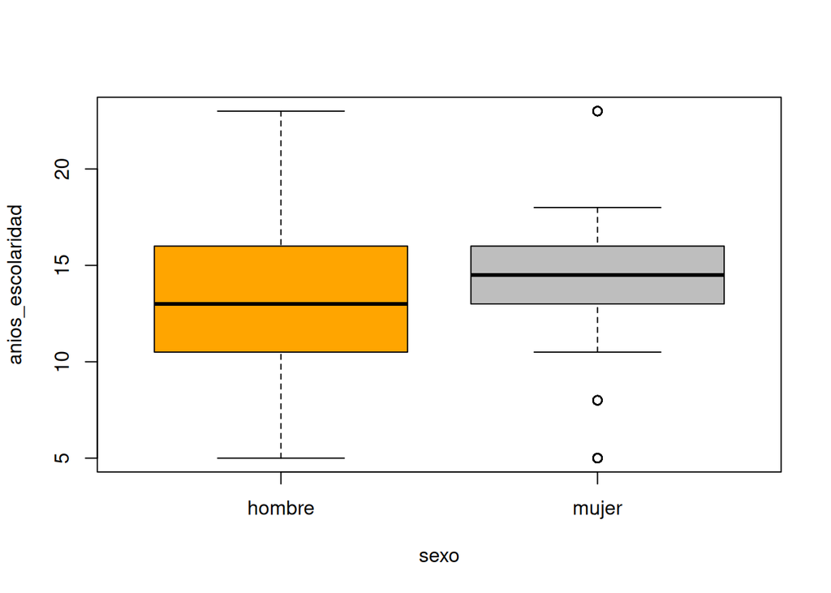

```r
boxplot(anios_escolaridad ~ sexo, data = df_data_estudios, col=c('orange','grey'))
```

## c. Revise la significancia de las variables.

> Los p-values asociados con los coeficientes son todos muy pequeños (menores que 0.05), lo que sugiere que hay evidencia estadística para afirmar que los coeficientes son diferentes de cero.

```r
mod_escolaridad <- lm( anios_escolaridad ~ edad + sexo,
             data = df_data_estudios)

summary(mod_escolaridad)
```

```
##
## Call:
## lm(formula = anios_escolaridad ~ edad + sexo, data = df_data_estudios)
##
## Residuals:
##     Min      1Q  Median      3Q     Max
## -9.3910 -2.6355 -0.1226  2.5403 10.1886
##
## Coefficients:
##              Estimate Std. Error t value Pr(>|t|)
## (Intercept) 13.770857   0.151885  90.666  < 2e-16 ***
## edad        -0.012966   0.003628  -3.574 0.000355 ***
## sexomujer    0.827607   0.108235   7.646 2.42e-14 ***
## ---
## Signif. codes:  0 '***' 0.001 '**' 0.01 '*' 0.05 '.' 0.1 ' ' 1
##
## Residual standard error: 3.95 on 5586 degrees of freedom
## Multiple R-squared:  0.01264,    Adjusted R-squared:  0.01229
## F-statistic: 35.77 on 2 and 5586 DF,  p-value: 3.677e-16
```

## d. Proponga los gráficos y tablas para sus hallazgos

```r
# Estimaciones

summary(mod_escolaridad$fitted.values)
```

```
##    Min. 1st Qu.  Median    Mean 3rd Qu.    Max.
##   12.67   13.25   13.49   13.61   14.05   14.42
```

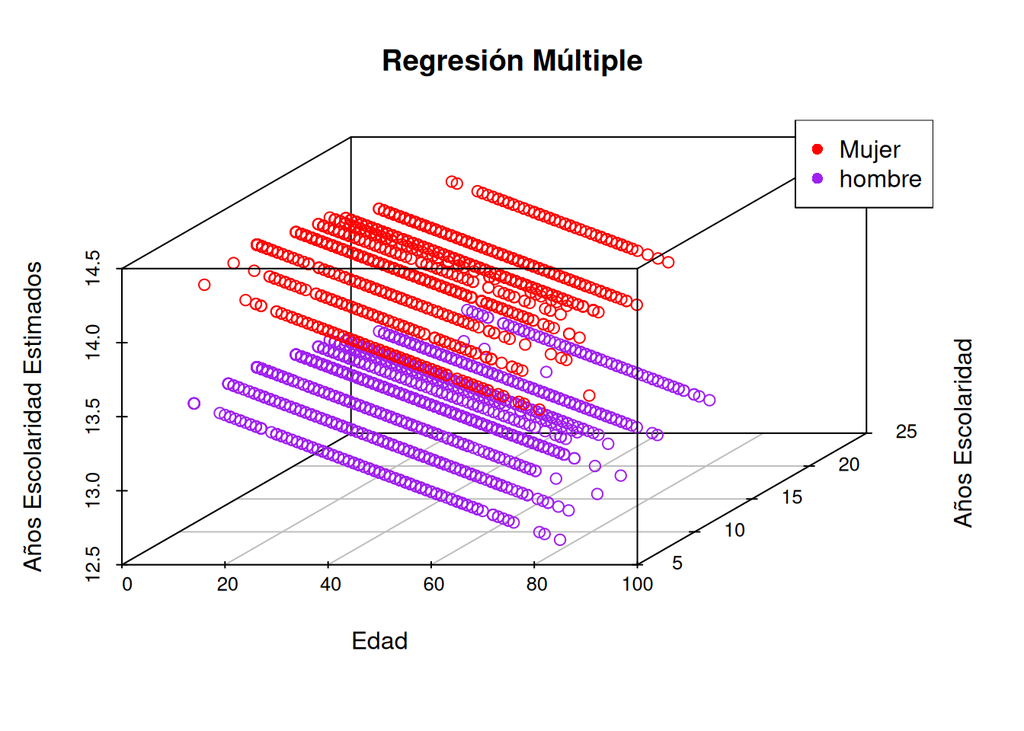

```r
mi_3d_escolaridad <- scatterplot3d(x=df_data_estudios$edad,
                       y=df_data_estudios$anios_escolaridad,
                       mod_escolaridad$fitted.values,
                       color = ifelse(df_data_estudios$sexo == "mujer", "red", "purple"),
                       main = "Regresión Múltiple",
                       xlab = "Edad",
                       ylab = "Años Escolaridad",
                       zlab = "Años Escolaridad Estimados"
                       )
legend("topright", legend = c("Mujer", "hombre"), col = c("red", "purple"), pch = c(16))
```

```r
# tabla de coeficientes del modelo de regresion multiple
coeficientes_mod <- coef(mod_escolaridad)
tabla_coeficientes <- as.data.frame(coeficientes_mod)
print(tabla_coeficientes)
```

```
##             coeficientes_mod
## (Intercept)      13.77085671
## edad             -0.01296584
## sexomujer         0.82760689
```